# EDA Sample

### Zip EDA Practice by Chiemi Kato

## About the Data Itself

There is a summary file containing data for each flight in the dataset. Then there are several datasets containing information about a singular flight. For these flight data sets, information is logged at various times starting from -5 seconds before the flight takes off to 15 seconds after the flight takes off.

### *Please note! I have moved all of the csv files into a folder called **'data'**. All commands in this project will refer to the csv files which are stored in this data folder.

```python
import pandas as pd
import matplotlib.pyplot as plt
import numpy as np
import glob
import math

from sklearn.model_selection import train_test_split
from sklearn.linear_model import LinearRegression
```

```python
csv1=pd.read_csv('data/flight_16951.csv')
```

### First let's look at just one csv file to get a feel for the variables

```python
csv1.head(n=10)
```

|  | seconds_since_launch | position_ned_m[0] | position_ned_m[1] | position_ned_m[2] | velocity_ned_mps[0] | velocity_ned_mps[1] | velocity_ned_mps[2] | accel_body_mps2[0] | accel_body_mps2[1] | accel_body_mps2[2] | orientation_rad[0] | orientation_rad[1] | orientation_rad[2] | angular_rate_body_radps[0] | angular_rate_body_radps[1] | angular_rate_body_radps[2] | position_sigma_ned_m[0] | position_sigma_ned_m[1] | position_sigma_ned_m[2] |
| --- | --- | --- | --- | --- | --- | --- | --- | --- | --- | --- | --- | --- | --- | --- | --- | --- | --- | --- | --- |
| 0 | -4.99846 | 5.143372 | 8.170100 | -4.561916 | 0.0 | 0.0 | 0.0 | 2.200169 | -0.059350 | -9.497843 | 0.007623 | 0.214396 | 2.741056 | 0.002011 | -0.000639 | 0.000495 | 0.186535 | 0.340824 | 0.428683 |
| 1 | -4.97846 | 5.143372 | 8.170100 | -4.561916 | 0.0 | 0.0 | 0.0 | 2.027999 | -0.053380 | -9.611131 | 0.007616 | 0.214414 | 2.741054 | 0.004984 | -0.000766 | 0.001946 | 0.186535 | 0.340824 | 0.428683 |
| 2 | -4.95833 | 5.143372 | 8.170100 | -4.561916 | 0.0 | 0.0 | 0.0 | 2.051773 | -0.264372 | -9.632382 | 0.007602 | 0.214424 | 2.741051 | 0.000886 | 0.002613 | -0.000127 | 0.186535 | 0.340824 | 0.428683 |
| 3 | -4.93848 | 5.143549 | 8.168812 | -4.561501 | 0.0 | 0.0 | 0.0 | 2.173164 | -0.113283 | -9.657514 | 0.007609 | 0.214409 | 2.741053 | -0.001839 | -0.001339 | -0.000740 | 0.186556 | 0.340836 | 0.428738 |
| 4 | -4.91848 | 5.143549 | 8.168812 | -4.561501 | 0.0 | 0.0 | 0.0 | 2.012778 | -0.045159 | -9.635982 | 0.007615 | 0.214412 | 2.741054 | 0.000497 | -0.000715 | 0.001186 | 0.186556 | 0.340836 | 0.428738 |
| 5 | -4.89849 | 5.143012 | 8.170419 | -4.563326 | 0.0 | 0.0 | 0.0 | 2.077366 | -0.070073 | -9.526079 | 0.007610 | 0.214417 | 2.741053 | 0.000475 | 0.001337 | 0.000074 | 0.186575 | 0.340849 | 0.428794 |
| 6 | -4.87850 | 5.143012 | 8.170419 | -4.563326 | 0.0 | 0.0 | 0.0 | 2.168130 | -0.001093 | -9.594013 | 0.007615 | 0.214402 | 2.741054 | 0.000139 | -0.002073 | -0.000767 | 0.186575 | 0.340849 | 0.428794 |
| 7 | -4.85848 | 5.143012 | 8.170419 | -4.563326 | 0.0 | 0.0 | 0.0 | 1.938173 | -0.068898 | -9.672871 | 0.007622 | 0.214410 | 2.741055 | 0.001792 | 0.000848 | 0.000303 | 0.186575 | 0.340849 | 0.428794 |
| 8 | -4.83851 | 5.143236 | 8.170900 | -4.565207 | 0.0 | 0.0 | 0.0 | 2.158677 | -0.156225 | -9.559793 | 0.007614 | 0.214424 | 2.741054 | -0.001104 | 0.002537 | -0.001246 | 0.186595 | 0.340861 | 0.428849 |
| 9 | -4.81852 | 5.143236 | 8.170900 | -4.565207 | 0.0 | 0.0 | 0.0 | 2.115438 | -0.032763 | -9.527992 | 0.007606 | 0.214389 | 2.741052 | -0.000456 | -0.002244 | 0.002054 | 0.186595 | 0.340861 | 0.428849 |

```python
csv1.columns
```

```
Index(['seconds_since_launch', 'position_ned_m[0]', 'position_ned_m[1]',
       'position_ned_m[2]', 'velocity_ned_mps[0]', 'velocity_ned_mps[1]',
       'velocity_ned_mps[2]', 'accel_body_mps2[0]', 'accel_body_mps2[1]',
       'accel_body_mps2[2]', 'orientation_rad[0]', 'orientation_rad[1]',
       'orientation_rad[2]', 'angular_rate_body_radps[0]',
       'angular_rate_body_radps[1]', 'angular_rate_body_radps[2]',
       'position_sigma_ned_m[0]', 'position_sigma_ned_m[1]',
       'position_sigma_ned_m[2]'],
      dtype='object')
```

```python
csv1.shape
```

```
(1001, 19)
```

```python
csv1.info()
```

```
<class 'pandas.core.frame.DataFrame'>
RangeIndex: 1001 entries, 0 to 1000
Data columns (total 19 columns):
seconds_since_launch          1001 non-null float64
position_ned_m[0]             1001 non-null float64
position_ned_m[1]             1001 non-null float64
position_ned_m[2]             1001 non-null float64
velocity_ned_mps[0]           1001 non-null float64
velocity_ned_mps[1]           1001 non-null float64
velocity_ned_mps[2]           1001 non-null float64
accel_body_mps2[0]            1001 non-null float64
accel_body_mps2[1]            1001 non-null float64
accel_body_mps2[2]            1001 non-null float64
orientation_rad[0]            1001 non-null float64
orientation_rad[1]            1001 non-null float64
orientation_rad[2]            1001 non-null float64
angular_rate_body_radps[0]    1001 non-null float64
angular_rate_body_radps[1]    1001 non-null float64
angular_rate_body_radps[2]    1001 non-null float64
position_sigma_ned_m[0]       1001 non-null float64
position_sigma_ned_m[1]       1001 non-null float64
position_sigma_ned_m[2]       1001 non-null float64
dtypes: float64(19)
memory usage: 148.7 KB
```

### Now for the summary data set...

```python
summ = pd.read_csv('data/summary_data.csv')
summ.head()
```

|  | flight_id | air_temperature | battery_serial_number | body_serial_number | commit | launch_airspeed | launch_groundspeed | launch_timestamp | preflight_voltage | rel_humidity | static_pressure | wind_direction | wind_magnitude | wing_serial_number |
| --- | --- | --- | --- | --- | --- | --- | --- | --- | --- | --- | --- | --- | --- | --- |
| 0 | 16951 | 20.550000 | 15SPJJJ09036021 | 577350132807348254 | 5c504d9a16 | 32.453445 | 30.164656 | 2018-09-06 07:43:59 CAT | NaN | 74.150000 | 80662.081736 | -49.434555 | 1.949338 | 15SPJJJ11024054 |
| 1 | 16952 | 20.500000 | 15SPJJJ10029029 | 577209618523054122 | 5c504d9a16 | 32.141209 | 30.535246 | 2018-09-06 07:51:49 CAT | NaN | 71.175044 | 80708.065314 | -4.408768 | 0.917357 | 15SPJJJ09011032 |
| 2 | 16954 | 24.475019 | 15SPJJJ10012034 | 577209618523054122 | 5c504d9a16 | 34.701878 | 29.872613 | 2018-09-06 09:56:37 CAT | NaN | 66.374982 | 80774.270438 | -23.458781 | 3.788383 | 15SPJJJ09011032 |
| 3 | 16955 | 27.300000 | 15SPJJJ10054027 | 577209618523082792 | 5c504d9a16 | 34.368999 | 29.877624 | 2018-09-06 10:27:04 CAT | NaN | 59.000000 | 80805.138793 | -46.747881 | 3.921605 | 15SPJJJ11049056 |
| 4 | 16957 | 26.950000 | 15SPJJJ10050049 | 577348835962150933 | 5c504d9a16 | 32.898979 | 30.027183 | 2018-09-06 11:09:39 CAT | NaN | 63.900000 | 80768.969307 | -29.293360 | 2.975881 | 15SPJJJ09031032 |

```python
summ.info()
```

```
<class 'pandas.core.frame.DataFrame'>
RangeIndex: 447 entries, 0 to 446
Data columns (total 14 columns):
flight_id                447 non-null int64
air_temperature          447 non-null float64
battery_serial_number    447 non-null object
body_serial_number       447 non-null int64
commit                   447 non-null object
launch_airspeed          447 non-null float64
launch_groundspeed       447 non-null float64
launch_timestamp         447 non-null object
preflight_voltage        431 non-null float64
rel_humidity             447 non-null float64
static_pressure          447 non-null float64
wind_direction           447 non-null float64
wind_magnitude           447 non-null float64
wing_serial_number       447 non-null object
dtypes: float64(8), int64(2), object(4)
memory usage: 49.0+ KB
```

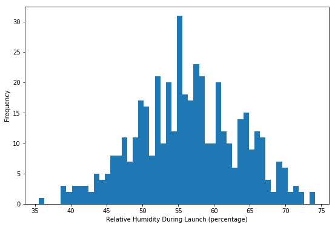

```python
plt.figure(figsize=(9,6))
plt.hist(summ.rel_humidity, bins=50)

plt.xlabel('Relative Humidity During Launch (percentage)')
plt.ylabel('Frequency')

plt.show()
```

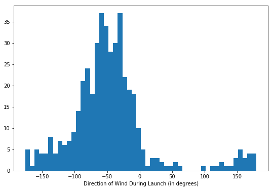

```python
plt.figure(figsize=(9,6))
plt.hist(summ.wind_direction, bins=50)

plt.xlabel('Direction of Wind During Launch (in degrees)')
plt.show()
```

#### There are some patterns we can already spot here in the wind_direction data from the summary data set. It looks like the wind direction is not evenly distributed, and that there is a higher frequency of observations having wind in the -50 direction than observations with wind in the 50 to 180 direction.

#### My guess about why the wind_direction data looks this way that geographic location might be the main factor... Say for instance, the Zip plane launch site is located next to the ocean and the wind often travels in the same direction every day according to the tide and ocean currents.

### Null Values in Summary Data

```python
summ.isnull().sum()
```

```
flight_id                 0
air_temperature           0
battery_serial_number     0
body_serial_number        0
commit                    0
launch_airspeed           0
launch_groundspeed        0
launch_timestamp          0
preflight_voltage        16
rel_humidity              0
static_pressure           0
wind_direction            0
wind_magnitude            0
wing_serial_number        0
dtype: int64
```

#### There are 16 mission values for preflight_voltage so we will omit those below using dropna() in the histogram command

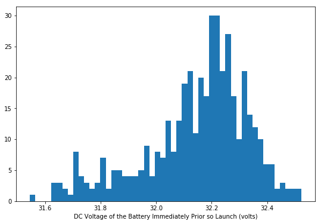

```python
plt.figure(figsize=(9,6))
plt.hist(summ.preflight_voltage.dropna(), bins=50)
plt.xlabel('DC Voltage of the Battery Immediately Prior so Launch (volts)')
plt.show()
```

# What Variables To Consider???

### The data in the summary data set includes information based off of not only the flight and Zip devices themselves, but also the weather and environmental factors during these flights as well.

### My idea for this exploratory data analysis is to focus on these environmental factors as explanatory variables to gauge whether they have any association to the flight data and performance.

## Organizing the Data

If we want to evaluate various relationships between the environmental factors recorded during the overall times of each flight, we can select just one timestamp from each flight csv in order to evaluate the records of each flight at amount of time relative to the launch time.

## Considerations

Ideally, we would like to be able measure product performance. My knowledge about drone performance is limited... But here is what my guess is as far as what we are looking for:

- We can look at the overall distributions of each of the columns from flight to flight... This means that across flights, if we fix a unit of relative time from launch (ie one specific time-stamped row from each flight csv), we can measure variables across columns (ie velocity or acceleration) from flight to flight
- If there are any *slower* Zip devices that are not moving at all or are slower than the rest, we can assume these are "low-performing" planes

#### Considerations Mentioned in The Video Are:

link: https://www.youtube.com/watch?v=jEbRVNxL44c

- Getting a plan *that* quickly into the air
- The narrator in the video states that each Zip is designed to be able to consistently take off within 0.3 seconds... We could test whether this is really true!

# Preprocessing Flight Data

```python
data_path = 'data'

values = list()
keys = list()
files = glob.glob(data_path + "/*.csv")
for i,f in enumerate(files):
    this_file = pd.read_csv(f)
    keys.append(f[12:17])
    values.append((list(this_file.iloc[len(this_file)-1,].values)))
```

```python
for i, items in enumerate(keys):
    keys[i] = int(items)
```

```
---------------------------------------------------------------------------
ValueError                                Traceback (most recent call last)
<ipython-input-14-ffa581a0e924> in <module>()
      1 for i, items in enumerate(keys):
----> 2     keys[i] = int(items)

ValueError: invalid literal for int() with base 10: '_data'
```

```python
type(keys[0])
keys[1:10]
```

```
[17076, 17704, 17738, 17274, 17512, 17506, 17300, 17466, 17314]
```

#### Before we construct the dataframe for all 448 flights, we will check to make sure that all of the number of columns is consistent for every element in the values list (should have 19 values stored in list)

```python
for i,items in enumerate(values):
    if len(items)!=19:
        print(i)
```

```
225
```

```python
keys[225]
```

```
'_data'
```

## It looks like there is one observation (row) which has a different number of columns than the rest

#### There is one data set (flight of list index #225) that does only has 14 columns!

If we check the key name of this observation to see where it came from by the keys[225] command above. The results show that it came from a csv file with '_data' in the original file name...

#### If we look at original set of csv files given for this exercise, we can see this data set actually comes from the summary_data.csv data set. Phew! The easy way to fix this is to simply omit (or 'pop') this observation out.

```python
len(values)
len(keys)
```

```
448
```

```python
values.pop(225)
keys.pop(225)
```

```
'_data'
```

Just to double check that we now have a consistent number of variables across

```python
for i,items in enumerate(values):
    if len(items)!=19:
        print(i)
```

It looks like there was an error when converting the values in the keys list from string to integer... let's check to make sure

```python
for i,item in enumerate(keys):
    if type(item)!=int:
        print(i)
```

```
225
226
227
228
229
230
231
232
233
234
235
236
237
238
239
240
241
242
243
244
245
246
247
248
249
250
251
252
253
254
255
256
257
258
259
260
261
262
263
264
```

[output cut: 167 more lines]

```
432
433
434
435
436
437
438
439
440
441
442
443
444
445
446
```

#### Half of the keys list (ie the flight numbers list) that we extracted from the names of the csv names were not converted from string to integer type!! We can see that after index #225, the keys names are not integers... We know that this error is due to the summary_data.csv causing an interruption in the conversion... Let's reconvert below.

```python
for i, items in enumerate(keys):
    keys[i] = int(items)
```

## Constructing the Flights DataFrame (df)

```python
nameofcolumns = np.array(this_file.iloc[1].keys())
nameofcolumns
```

```
array(['seconds_since_launch', 'position_ned_m[0]', 'position_ned_m[1]',
       'position_ned_m[2]', 'velocity_ned_mps[0]', 'velocity_ned_mps[1]',
       'velocity_ned_mps[2]', 'accel_body_mps2[0]', 'accel_body_mps2[1]',
       'accel_body_mps2[2]', 'orientation_rad[0]', 'orientation_rad[1]',
       'orientation_rad[2]', 'angular_rate_body_radps[0]',
       'angular_rate_body_radps[1]', 'angular_rate_body_radps[2]',
       'position_sigma_ned_m[0]', 'position_sigma_ned_m[1]',
       'position_sigma_ned_m[2]'], dtype=object)
```

```python
zipped = list(zip(keys,values))
dictionary = dict(zipped)

df = pd.DataFrame.from_dict(dictionary, orient='index', columns=nameofcolumns)
```

#### Are indices unique?

```python
df.index.unique()
```

```
Int64Index([17710, 17076, 17704, 17738, 17274, 17512, 17506, 17300, 17466,
            17314,
            ...
            16985, 17325, 17319, 17286, 17292, 17245, 17251, 17084, 17735,
            17709],
           dtype='int64', length=447)
```

#### 447 unique indices out of 447 total rows... So yes they are!

```python
df.head()
```

|  | seconds_since_launch | position_ned_m[0] | position_ned_m[1] | position_ned_m[2] | velocity_ned_mps[0] | velocity_ned_mps[1] | velocity_ned_mps[2] | accel_body_mps2[0] | accel_body_mps2[1] | accel_body_mps2[2] | orientation_rad[0] | orientation_rad[1] | orientation_rad[2] | angular_rate_body_radps[0] | angular_rate_body_radps[1] | angular_rate_body_radps[2] | position_sigma_ned_m[0] | position_sigma_ned_m[1] | position_sigma_ned_m[2] |
| --- | --- | --- | --- | --- | --- | --- | --- | --- | --- | --- | --- | --- | --- | --- | --- | --- | --- | --- | --- |
| 17710 | 14.99538 | -402.01364 | 183.91696 | -77.244010 | -25.057083 | 14.831861 | -0.270522 | 1.780158 | 0.173524 | -6.940281 | -0.433194 | 0.035833 | 2.433114 | -0.051139 | 0.047221 | -0.078046 | 0.629920 | 0.590247 | 0.580753 |
| 17076 | 14.99539 | -392.72437 | 178.21115 | -77.292430 | -24.441086 | 13.430227 | -1.829481 | 1.769006 | 0.302980 | -5.841938 | -0.365790 | 0.062143 | 2.574835 | -0.152290 | -0.077403 | -0.087242 | 0.491978 | 0.759933 | 0.551391 |
| 17704 | 14.99552 | -387.50960 | 177.33548 | -76.949814 | -24.139755 | 12.700197 | -1.923177 | 1.706362 | 0.195711 | -5.299113 | -0.286067 | 0.089996 | 2.475121 | -0.265571 | -0.002783 | -0.139931 | 0.440153 | 0.474459 | 0.345198 |
| 17738 | 14.99532 | -386.57623 | 175.53940 | -76.378630 | -24.321123 | 13.504090 | -2.039389 | 1.458785 | -0.161812 | -4.135351 | -0.236569 | 0.056748 | 2.521331 | -0.162845 | -0.080307 | -0.126068 | 0.030328 | 0.030717 | 0.082319 |
| 17274 | 14.99549 | -387.01587 | 176.62283 | -76.557144 | -23.157654 | 12.746631 | -2.274825 | 1.094811 | 0.137128 | -4.895300 | -0.276462 | 0.057332 | 2.366463 | -0.023481 | -0.079777 | -0.116450 | 0.005234 | 0.006850 | 0.010925 |

## Looking at Data Across Different Flights

```python
df.isnull().sum()
```

```
seconds_since_launch          0
position_ned_m[0]             0
position_ned_m[1]             0
position_ned_m[2]             0
velocity_ned_mps[0]           0
velocity_ned_mps[1]           0
velocity_ned_mps[2]           0
accel_body_mps2[0]            0
accel_body_mps2[1]            0
accel_body_mps2[2]            0
orientation_rad[0]            0
orientation_rad[1]            0
orientation_rad[2]            0
angular_rate_body_radps[0]    0
angular_rate_body_radps[1]    0
angular_rate_body_radps[2]    0
position_sigma_ned_m[0]       0
position_sigma_ned_m[1]       0
position_sigma_ned_m[2]       0
dtype: int64
```

```python
df.describe()
```

|  | seconds_since_launch | position_ned_m[0] | position_ned_m[1] | position_ned_m[2] | velocity_ned_mps[0] | velocity_ned_mps[1] | velocity_ned_mps[2] | accel_body_mps2[0] | accel_body_mps2[1] | accel_body_mps2[2] | orientation_rad[0] | orientation_rad[1] | orientation_rad[2] | angular_rate_body_radps[0] | angular_rate_body_radps[1] | angular_rate_body_radps[2] | position_sigma_ned_m[0] | position_sigma_ned_m[1] | position_sigma_ned_m[2] |
| --- | --- | --- | --- | --- | --- | --- | --- | --- | --- | --- | --- | --- | --- | --- | --- | --- | --- | --- | --- |
| count | 447.000000 | 447.000000 | 447.000000 | 447.000000 | 447.000000 | 447.000000 | 447.000000 | 447.000000 | 447.000000 | 447.000000 | 447.000000 | 447.000000 | 447.000000 | 447.000000 | 447.000000 | 447.000000 | 447.000000 | 447.000000 | 447.000000 |
| mean | 14.995431 | -389.288264 | 180.029193 | -76.356881 | -23.896058 | 14.165493 | -1.800199 | 1.461183 | 0.121709 | -6.295471 | -0.332475 | 0.070198 | 2.530633 | -0.113522 | -0.075451 | -0.091579 | 0.372822 | 0.397702 | 0.399473 |
| std | 0.000100 | 78.230047 | 28.271104 | 2.136531 | 4.966401 | 2.725117 | 1.435880 | 0.538498 | 0.215164 | 2.005091 | 0.094881 | 0.063490 | 0.277400 | 0.116902 | 0.083385 | 0.039666 | 0.353032 | 0.321280 | 0.273633 |
| min | 14.995020 | -449.437680 | -99.976980 | -79.652600 | -26.940681 | -5.024431 | -5.728644 | -0.769874 | -0.846489 | -12.014567 | -0.538931 | -0.046288 | -0.206493 | -0.664020 | -0.416873 | -0.255166 | 0.003706 | 0.003351 | 0.007177 |
| 25% | 14.995380 | -401.452740 | 176.968025 | -77.386280 | -25.108351 | 13.142601 | -2.700024 | 1.336330 | -0.011134 | -7.436076 | -0.392714 | 0.031235 | 2.504649 | -0.170484 | -0.129035 | -0.110007 | 0.039922 | 0.038755 | 0.097363 |
| 50% | 14.995420 | -394.461550 | 180.801710 | -76.851570 | -24.494303 | 13.994053 | -1.574270 | 1.536589 | 0.125387 | -6.248054 | -0.340275 | 0.057066 | 2.572468 | -0.123333 | -0.064343 | -0.088062 | 0.379118 | 0.439869 | 0.441709 |
| 75% | 14.995470 | -388.627635 | 185.137765 | -76.161165 | -23.670628 | 14.917084 | -0.668173 | 1.757215 | 0.257059 | -4.913185 | -0.284069 | 0.088743 | 2.623665 | -0.060573 | -0.019830 | -0.071456 | 0.529603 | 0.567716 | 0.540875 |
| max | 14.996050 | 432.789670 | 229.431870 | -62.728863 | 29.525553 | 23.522377 | 1.248411 | 2.835990 | 0.925697 | 1.784031 | 0.391116 | 0.267735 | 2.809036 | 0.414849 | 0.127570 | 0.124162 | 2.133611 | 2.341258 | 1.427157 |

### Large Variance in Variable 'position_ned_m[0]' - position of plane in North direction

It looks like there is a huge amount of variance in the position of the planes in the north direction (position_ned_m[0]), since the standard deviation of this column is 78m! Let's take a closer look.

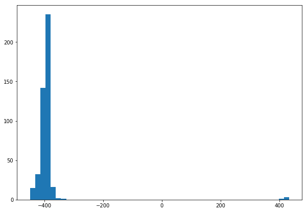

```python
plt.figure(figsize=(10,7))
plt.hist(df['position_ned_m[0]'], bins=50)
plt.show()
```

```python
filter = df['position_ned_m[0]'] > 350

subset = df.loc[filter]
subset
```

|  | seconds_since_launch | position_ned_m[0] | position_ned_m[1] | position_ned_m[2] | velocity_ned_mps[0] | velocity_ned_mps[1] | velocity_ned_mps[2] | accel_body_mps2[0] | accel_body_mps2[1] | accel_body_mps2[2] | orientation_rad[0] | orientation_rad[1] | orientation_rad[2] | angular_rate_body_radps[0] | angular_rate_body_radps[1] | angular_rate_body_radps[2] | position_sigma_ned_m[0] | position_sigma_ned_m[1] | position_sigma_ned_m[2] |
| --- | --- | --- | --- | --- | --- | --- | --- | --- | --- | --- | --- | --- | --- | --- | --- | --- | --- | --- | --- |
| 17439 | 14.99534 | 409.84918 | -96.011880 | -75.32695 | 25.176031 | -5.024431 | -3.912058 | 1.536589 | 0.100690 | -6.665611 | 0.183320 | 0.160481 | -0.163199 | 0.143232 | -0.221211 | 0.094253 | 0.735943 | 0.534366 | 0.772141 |
| 17438 | 14.99538 | 415.16324 | -97.168320 | -76.30206 | 26.811869 | -4.845245 | -2.554158 | 1.409086 | -0.018711 | -6.423633 | 0.255143 | 0.086847 | -0.149545 | 0.109027 | -0.156478 | 0.123846 | 0.037836 | 0.023308 | 0.090629 |
| 17437 | 14.99541 | 419.52500 | -98.897285 | -76.67538 | 26.738869 | -4.970031 | -2.131201 | 1.372268 | -0.181096 | -3.098326 | 0.298077 | 0.061634 | -0.172156 | 0.187282 | -0.141424 | 0.124162 | 0.457886 | 0.461330 | 0.508027 |
| 17136 | 14.99532 | 432.78967 | -99.976980 | -77.39478 | 29.525553 | -4.375762 | -0.960295 | 1.347475 | 0.013447 | -6.239941 | 0.391116 | 0.006418 | -0.206493 | 0.187641 | -0.060213 | 0.100006 | 0.006517 | 0.007886 | 0.017245 |

```python
mean_compare = pd.concat([subset.mean(), df.mean()], axis=1)

mean_compare.columns = ['Outlier Flights','All Flights']
```

```python
mean_compare['diff']='TBD'

for index, values in mean_compare.iterrows():
    mean_compare.loc[index, 'diff']= values[1]-values[0]

mean_compare.sort_values('diff', ascending=True)
```

|  | Outlier Flights | All Flights | diff |
| --- | --- | --- | --- |
| position_ned_m[0] | 419.331773 | -389.288264 | -808.62 |
| velocity_ned_mps[0] | 27.063080 | -23.896058 | -50.9591 |
| accel_body_mps2[2] | -5.606878 | -6.295471 | -0.688593 |
| orientation_rad[0] | 0.281914 | -0.332475 | -0.614389 |
| angular_rate_body_radps[0] | 0.156795 | -0.113522 | -0.270317 |
| angular_rate_body_radps[2] | 0.110567 | -0.091579 | -0.202146 |
| orientation_rad[1] | 0.078845 | 0.070198 | -0.00864692 |
| seconds_since_launch | 14.995363 | 14.995431 | 6.86556e-05 |
| accel_body_mps2[0] | 1.416354 | 1.461183 | 0.0448287 |
| position_sigma_ned_m[2] | 0.347011 | 0.399473 | 0.052462 |
| position_sigma_ned_m[0] | 0.309546 | 0.372822 | 0.0632764 |
| position_ned_m[2] | -76.424793 | -76.356881 | 0.0679117 |
| angular_rate_body_radps[1] | -0.144831 | -0.075451 | 0.0693805 |
| position_sigma_ned_m[1] | 0.256723 | 0.397702 | 0.140979 |
| accel_body_mps2[1] | -0.021418 | 0.121709 | 0.143127 |
| velocity_ned_mps[2] | -2.389428 | -1.800199 | 0.589229 |
| orientation_rad[2] | -0.172848 | 2.530633 | 2.70348 |
| velocity_ned_mps[1] | -4.803867 | 14.165493 | 18.9694 |
| position_ned_m[1] | -98.013616 | 180.029193 | 278.043 |

#### There are only four observations in our outliers set compared to the hundreds of observations in the full flights set; however, just by looking at the summary of the means taken from each of the columns in the data sets above, we can see that some variables are relatively similar, whereas others have a large difference.

Besides the position_ned_m[0] variable, velocity_ned_mps[1] and velocity_ned_mps[0] also have large differences between the two groups. These results are interesting, especially since we used the North position (position [0]) vector to subset the data, but it seems the velocity[1] performance of the plan may be associated somehow as well.

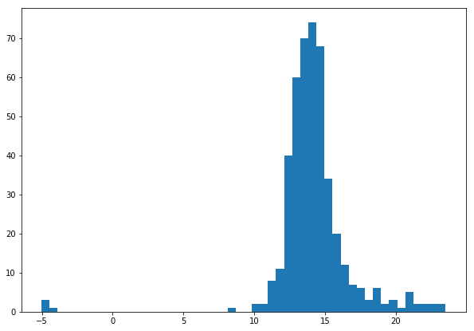

```python
plt.figure(figsize=(10,7))
plt.hist(df['velocity_ned_mps[1]'], bins=50)
plt.show()
```

```python
filter2 = df['velocity_ned_mps[1]']<0

df.loc[filter2]
```

|  | seconds_since_launch | position_ned_m[0] | position_ned_m[1] | position_ned_m[2] | velocity_ned_mps[0] | velocity_ned_mps[1] | velocity_ned_mps[2] | accel_body_mps2[0] | accel_body_mps2[1] | accel_body_mps2[2] | orientation_rad[0] | orientation_rad[1] | orientation_rad[2] | angular_rate_body_radps[0] | angular_rate_body_radps[1] | angular_rate_body_radps[2] | position_sigma_ned_m[0] | position_sigma_ned_m[1] | position_sigma_ned_m[2] |
| --- | --- | --- | --- | --- | --- | --- | --- | --- | --- | --- | --- | --- | --- | --- | --- | --- | --- | --- | --- |
| 17439 | 14.99534 | 409.84918 | -96.011880 | -75.32695 | 25.176031 | -5.024431 | -3.912058 | 1.536589 | 0.100690 | -6.665611 | 0.183320 | 0.160481 | -0.163199 | 0.143232 | -0.221211 | 0.094253 | 0.735943 | 0.534366 | 0.772141 |
| 17438 | 14.99538 | 415.16324 | -97.168320 | -76.30206 | 26.811869 | -4.845245 | -2.554158 | 1.409086 | -0.018711 | -6.423633 | 0.255143 | 0.086847 | -0.149545 | 0.109027 | -0.156478 | 0.123846 | 0.037836 | 0.023308 | 0.090629 |
| 17437 | 14.99541 | 419.52500 | -98.897285 | -76.67538 | 26.738869 | -4.970031 | -2.131201 | 1.372268 | -0.181096 | -3.098326 | 0.298077 | 0.061634 | -0.172156 | 0.187282 | -0.141424 | 0.124162 | 0.457886 | 0.461330 | 0.508027 |
| 17136 | 14.99532 | 432.78967 | -99.976980 | -77.39478 | 29.525553 | -4.375762 | -0.960295 | 1.347475 | 0.013447 | -6.239941 | 0.391116 | 0.006418 | -0.206493 | 0.187641 | -0.060213 | 0.100006 | 0.006517 | 0.007886 | 0.017245 |

#### The four outlier flights listed above are the same flights that have outliers in the position[0] vector as well...

The scatterplot below compares overall velocity[1] performance to velocity[0] performance, since these variables seemed to be the most associated with the position[0] location vector. The data points in with a red + are the four flights, 17136, 17437, 17438, and 17439.

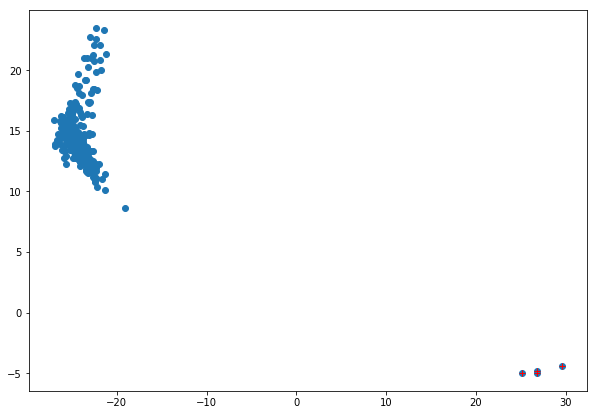

```python
plt.figure(figsize=(10,7))
plt.scatter(df['velocity_ned_mps[0]'],df['velocity_ned_mps[1]'])
plt.plot(df.loc[17439,'velocity_ned_mps[0]'], df.loc[17439,'velocity_ned_mps[1]'], 'r+')
plt.plot(df.loc[17438,'velocity_ned_mps[0]'], df.loc[17438,'velocity_ned_mps[1]'], 'r+')
plt.plot(df.loc[17437,'velocity_ned_mps[0]'], df.loc[17437,'velocity_ned_mps[1]'], 'r+')
plt.plot(df.loc[17136,'velocity_ned_mps[0]'], df.loc[17136,'velocity_ned_mps[1]'], 'r+')
plt.show()
```

### Conclusion About The Four Outliers

Because the four outlier flights listed above have almost all consecutive flight IDs (17437, 17428, 17439, and then 17136)... We may be able to draw further insights about this group/batch of planes by looking at the conditions of the plane manufacturing or the weather conditions during the time of these flights...

For a cleaner data set, I would recommend taking out these outliers for further investigation of the rest of the data. Because there is no specific business/production/analytical goals for this Exploratory Data Analysis exercise, I wasn't sure whether to take them out or not... But for fun, I went on ahead and took these four flights out just to see how the standard deviation/variance would change. **Note, position_ned_m[0] column had a previous std of 78.2300 and the position_ned_m[1] column had a previous std of 28.2711.**

```python
df = df.drop([17437, 17438, 17439, 17136], axis=0)
```

```python
for i in [17437, 17438, 17439, 17136]:
    if i in summ['flight_id'].values:
        print(i)
    else:
        print('flight', i, 'is not in the summ data set')
```

```
17437
17438
17439
17136
```

```python
for i in [17437, 17438, 17439, 17136]:
    print(summ[summ['flight_id'] == i].index.item())
```

```
252
253
254
90
```

```python
summ = summ.drop([90, 252, 253, 254], axis=0)
```

```python
df.describe()
```

|  | seconds_since_launch | position_ned_m[0] | position_ned_m[1] | position_ned_m[2] | velocity_ned_mps[0] | velocity_ned_mps[1] | velocity_ned_mps[2] | accel_body_mps2[0] | accel_body_mps2[1] | accel_body_mps2[2] | orientation_rad[0] | orientation_rad[1] | orientation_rad[2] | angular_rate_body_radps[0] | angular_rate_body_radps[1] | angular_rate_body_radps[2] | position_sigma_ned_m[0] | position_sigma_ned_m[1] | position_sigma_ned_m[2] |
| --- | --- | --- | --- | --- | --- | --- | --- | --- | --- | --- | --- | --- | --- | --- | --- | --- | --- | --- | --- |
| count | 443.000000 | 443.000000 | 443.000000 | 443.000000 | 443.000000 | 443.000000 | 443.000000 | 443.000000 | 443.000000 | 443.000000 | 443.000000 | 443.000000 | 443.000000 | 443.000000 | 443.000000 | 443.000000 | 443.000000 | 443.000000 | 443.000000 |
| mean | 14.995432 | -396.589574 | 182.539737 | -76.356268 | -24.356185 | 14.336774 | -1.794879 | 1.461588 | 0.123001 | -6.301689 | -0.338022 | 0.070120 | 2.555044 | -0.115962 | -0.074824 | -0.093404 | 0.373393 | 0.398975 | 0.399946 |
| std | 0.000101 | 14.279334 | 10.026565 | 2.144994 | 1.073891 | 2.051106 | 1.437762 | 0.540868 | 0.215483 | 2.008296 | 0.074738 | 0.063554 | 0.104416 | 0.114511 | 0.083321 | 0.034825 | 0.353394 | 0.321623 | 0.273249 |
| min | 14.995020 | -449.437680 | 146.302920 | -79.652600 | -26.940681 | 8.621500 | -5.728644 | -0.769874 | -0.846489 | -12.014567 | -0.538931 | -0.046288 | 2.113633 | -0.664020 | -0.416873 | -0.255166 | 0.003706 | 0.003351 | 0.007177 |
| 25% | 14.995380 | -401.587100 | 177.022050 | -77.386280 | -25.111484 | 13.174273 | -2.700024 | 1.329077 | -0.008136 | -7.455115 | -0.393471 | 0.031235 | 2.506012 | -0.170649 | -0.128061 | -0.110508 | 0.042252 | 0.040700 | 0.110731 |
| 50% | 14.995420 | -394.544530 | 180.863140 | -76.876930 | -24.512901 | 14.013165 | -1.572386 | 1.539271 | 0.127224 | -6.248054 | -0.341790 | 0.056790 | 2.573202 | -0.124635 | -0.063342 | -0.088277 | 0.379118 | 0.439869 | 0.441709 |
| 75% | 14.995470 | -388.759430 | 185.184970 | -76.161165 | -23.692770 | 14.918558 | -0.648918 | 1.759415 | 0.258631 | -4.913185 | -0.285030 | 0.088743 | 2.623896 | -0.067014 | -0.019483 | -0.072087 | 0.529603 | 0.569514 | 0.540875 |
| max | 14.996050 | -326.684420 | 229.431870 | -62.728863 | -19.065804 | 23.522377 | 1.248411 | 2.835990 | 0.925697 | 1.784031 | -0.072913 | 0.267735 | 2.809036 | 0.414849 | 0.127570 | 0.009035 | 2.133611 | 2.341258 | 1.427157 |

## Now Let's Join Our 2 Dataframes

Using the flight_id as the primary key of this new data set, let's create a new dataframe that has 1 row for each Zip flight, with information from both summ and df dataframes

```python
summ = summ.set_index('flight_id')
```

```python
summ.head()
```

| flight_id | air_temperature | battery_serial_number | body_serial_number | commit | launch_airspeed | launch_groundspeed | launch_timestamp | preflight_voltage | rel_humidity | static_pressure | wind_direction | wind_magnitude | wing_serial_number |
| --- | --- | --- | --- | --- | --- | --- | --- | --- | --- | --- | --- | --- | --- |
| 16951 | 20.550000 | 15SPJJJ09036021 | 577350132807348254 | 5c504d9a16 | 32.453445 | 30.164656 | 2018-09-06 07:43:59 CAT | NaN | 74.150000 | 80662.081736 | -49.434555 | 1.949338 | 15SPJJJ11024054 |
| 16952 | 20.500000 | 15SPJJJ10029029 | 577209618523054122 | 5c504d9a16 | 32.141209 | 30.535246 | 2018-09-06 07:51:49 CAT | NaN | 71.175044 | 80708.065314 | -4.408768 | 0.917357 | 15SPJJJ09011032 |
| 16954 | 24.475019 | 15SPJJJ10012034 | 577209618523054122 | 5c504d9a16 | 34.701878 | 29.872613 | 2018-09-06 09:56:37 CAT | NaN | 66.374982 | 80774.270438 | -23.458781 | 3.788383 | 15SPJJJ09011032 |
| 16955 | 27.300000 | 15SPJJJ10054027 | 577209618523082792 | 5c504d9a16 | 34.368999 | 29.877624 | 2018-09-06 10:27:04 CAT | NaN | 59.000000 | 80805.138793 | -46.747881 | 3.921605 | 15SPJJJ11049056 |
| 16957 | 26.950000 | 15SPJJJ10050049 | 577348835962150933 | 5c504d9a16 | 32.898979 | 30.027183 | 2018-09-06 11:09:39 CAT | NaN | 63.900000 | 80768.969307 | -29.293360 | 2.975881 | 15SPJJJ09031032 |

```python
combined = summ.join(df)

combined.head(5)
```

| flight_id | air_temperature | battery_serial_number | body_serial_number | commit | launch_airspeed | launch_groundspeed | launch_timestamp | preflight_voltage | rel_humidity | static_pressure | ... | accel_body_mps2[2] | orientation_rad[0] | orientation_rad[1] | orientation_rad[2] | angular_rate_body_radps[0] | angular_rate_body_radps[1] | angular_rate_body_radps[2] | position_sigma_ned_m[0] | position_sigma_ned_m[1] | position_sigma_ned_m[2] |
| --- | --- | --- | --- | --- | --- | --- | --- | --- | --- | --- | --- | --- | --- | --- | --- | --- | --- | --- | --- | --- | --- |
| 16951 | 20.550000 | 15SPJJJ09036021 | 577350132807348254 | 5c504d9a16 | 32.453445 | 30.164656 | 2018-09-06 07:43:59 CAT | NaN | 74.150000 | 80662.081736 | ... | -4.156568 | -0.285183 | 0.068529 | 2.599779 | -0.145041 | -0.113501 | -0.087676 | 0.129551 | 0.225514 | 0.296766 |
| 16952 | 20.500000 | 15SPJJJ10029029 | 577209618523054122 | 5c504d9a16 | 32.141209 | 30.535246 | 2018-09-06 07:51:49 CAT | NaN | 71.175044 | 80708.065314 | ... | -5.312444 | -0.396258 | 0.071361 | 2.666603 | -0.143309 | -0.049896 | -0.060866 | 0.440123 | 0.450459 | 0.468057 |
| 16954 | 24.475019 | 15SPJJJ10012034 | 577209618523054122 | 5c504d9a16 | 34.701878 | 29.872613 | 2018-09-06 09:56:37 CAT | NaN | 66.374982 | 80774.270438 | ... | -5.771955 | -0.264105 | 0.154721 | 2.659648 | -0.103265 | -0.154996 | -0.114805 | 0.544848 | 0.602897 | 0.531991 |
| 16955 | 27.300000 | 15SPJJJ10054027 | 577209618523082792 | 5c504d9a16 | 34.368999 | 29.877624 | 2018-09-06 10:27:04 CAT | NaN | 59.000000 | 80805.138793 | ... | -9.624934 | -0.231785 | 0.194967 | 2.600351 | -0.074000 | -0.131669 | -0.063767 | 0.361827 | 0.495776 | 0.341767 |
| 16957 | 26.950000 | 15SPJJJ10050049 | 577348835962150933 | 5c504d9a16 | 32.898979 | 30.027183 | 2018-09-06 11:09:39 CAT | NaN | 63.900000 | 80768.969307 | ... | -5.644479 | -0.264978 | 0.158007 | 2.624602 | -0.134525 | -0.150615 | -0.137181 | 0.019826 | 0.028119 | 0.067745 |

5 rows × 32 columns

### Check for Null Values and Unmatched Flight Observations

```python
combined.isnull().sum()
```

```
air_temperature                0
battery_serial_number          0
body_serial_number             0
commit                         0
launch_airspeed                0
launch_groundspeed             0
launch_timestamp               0
preflight_voltage             16
rel_humidity                   0
static_pressure                0
wind_direction                 0
wind_magnitude                 0
wing_serial_number             0
seconds_since_launch           0
position_ned_m[0]              0
position_ned_m[1]              0
position_ned_m[2]              0
velocity_ned_mps[0]            0
velocity_ned_mps[1]            0
velocity_ned_mps[2]            0
accel_body_mps2[0]             0
accel_body_mps2[1]             0
accel_body_mps2[2]             0
orientation_rad[0]             0
orientation_rad[1]             0
orientation_rad[2]             0
angular_rate_body_radps[0]     0
angular_rate_body_radps[1]     0
angular_rate_body_radps[2]     0
position_sigma_ned_m[0]        0
position_sigma_ned_m[1]        0
position_sigma_ned_m[2]        0
dtype: int64
```

#### Results: Nice! We didn't even need to use an inner join!

There were no mismatched flight observations between our summary data set and the aggregated (over fixed relative time) flights data set. We do however still have the same 16 missing preflight_voltage observations from our Zip plane flight!

If I had more time, I look deeper in to these missing preflight_voltage values to see if there were any patterns or insights from these 16 data flights. But for now, let's just go ahead and omit these from our final combined data set.

```python
len(combined)
```

```
443
```

```python
combined = combined.dropna()
len(combined)
```

```
427
```

# Drawing Insights

#### Now that we have one complete dataframe to work with (having 427 separate flight observations), we can take a deeper look at various relationships.

## Consider Wind Magnitude and Wind Direction as Categories

To be able to better understand the relationships between the aspects of the weather conditions and Zip plane performance, let's consider the wind_magnitude and wind_direction variables to see if we can spot any patterns.

First, let's reclassify and group our numeric variables, wind_magnitude and wind_direction, to help us look for patterns.

## Evaluating Wind Magnitude

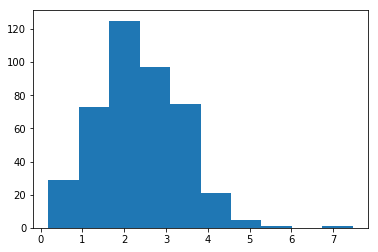

```python
plt.hist(combined.wind_magnitude)
```

```python
combined.wind_magnitude.describe()
```

```
count    427.000000
mean       2.362705
std        1.002112
min        0.188798
25%        1.693854
50%        2.294640
75%        3.062859
max        7.466193
Name: wind_magnitude, dtype: float64
```

```python
combined['wind_mag_factor'] = 'TBD'

def wind_mag_class(wind_float):
    if (0.188798<= wind_float < 1.703303):
        return 'Lower Quartile'
    elif (1.703303 <= wind_float <2.307687):
        return 'Second Quartile'
    elif (2.307687 <= wind_float <3.006968):
        return 'Third Quartile'
    else:
        return 'Upper Quartile'
```

```python
for index, values in combined.iterrows():
    combined.loc[index, 'wind_mag_factor'] = wind_mag_class(combined.loc[index, 'wind_magnitude'])
```

```python
combined.wind_mag_factor.head()
```

```
flight_id
16985    Lower Quartile
16987    Lower Quartile
16989    Lower Quartile
16990    Lower Quartile
16991    Upper Quartile
Name: wind_mag_factor, dtype: object
```

```python
windy = combined.loc[combined['wind_mag_factor'] == 'Upper Quartile']
```

```python
mean_compare2 = pd.concat([windy.mean(), combined.mean()], axis=1)
```

```python
mean_compare2.columns = ['Upper Quartile Wind (Windy) Flights AVGs', 'All Flights AVGs']
```

```python
mean_compare2['diff'] = 'TBD'

for index, values in mean_compare2.iterrows():
    mean_compare2.loc[index, 'diff'] = values[1]-values[0]
```

```python
mean_compare2.sort_values('diff', ascending=False)
```

|  | Upper Quartile Wind (Windy) Flights AVGs | All Flights AVGs | diff |
| --- | --- | --- | --- |
| wind_direction | -5.692535e+01 | -4.969106e+01 | 7.2343 |
| static_pressure | 8.044705e+04 | 8.045125e+04 | 4.20615 |
| position_ned_m[1] | 1.782629e+02 | 1.823570e+02 | 4.09408 |
| rel_humidity | 5.488326e+01 | 5.600604e+01 | 1.12278 |
| velocity_ned_mps[1] | 1.332031e+01 | 1.429327e+01 | 0.972963 |
| velocity_ned_mps[2] | -2.328385e+00 | -1.750533e+00 | 0.577852 |
| accel_body_mps2[0] | 1.213247e+00 | 1.450926e+00 | 0.237679 |
| launch_groundspeed | 3.005770e+01 | 3.010461e+01 | 0.0469132 |
| accel_body_mps2[1] | 9.255022e-02 | 1.182487e-01 | 0.0256985 |
| angular_rate_body_radps[1] | -9.942983e-02 | -7.491256e-02 | 0.0245173 |
| position_sigma_ned_m[0] | 3.667208e-01 | 3.781581e-01 | 0.0114373 |
| position_sigma_ned_m[2] | 3.949713e-01 | 4.046272e-01 | 0.00965588 |
| position_sigma_ned_m[1] | 3.938317e-01 | 4.021727e-01 | 0.00834104 |
| orientation_rad[2] | 2.550092e+00 | 2.555792e+00 | 0.00569962 |
| seconds_since_launch | 1.499544e+01 | 1.499543e+01 | -1.30928e-05 |
| preflight_voltage | 3.214768e+01 | 3.214649e+01 | -0.00118992 |
| angular_rate_body_radps[2] | -8.982499e-02 | -9.280081e-02 | -0.00297582 |
| orientation_rad[1] | 7.918387e-02 | 6.770502e-02 | -0.0114789 |
| angular_rate_body_radps[0] | -9.839589e-02 | -1.160035e-01 | -0.0176076 |
| orientation_rad[0] | -2.910590e-01 | -3.378981e-01 | -0.0468391 |
| air_temperature | 2.537387e+01 | 2.531493e+01 | -0.0589442 |
| accel_body_mps2[2] | -6.027347e+00 | -6.269928e+00 | -0.242581 |
| position_ned_m[2] | -7.603625e+01 | -7.645380e+01 | -0.417555 |
| velocity_ned_mps[0] | -2.371910e+01 | -2.438323e+01 | -0.664135 |
| launch_airspeed | 3.318294e+01 | 3.196328e+01 | -1.21966 |
| wind_magnitude | 3.613440e+00 | 2.362705e+00 | -1.25073 |
| position_ned_m[0] | -3.895233e+02 | -3.963748e+02 | -6.85155 |
| body_serial_number | 5.773409e+17 | 5.773386e+17 | -2.27716e+12 |

## Comments on Noticeable Patterns of "Windy" Flights (Upper Quartile of wind_magnitude)

Below are scatterplots of these two variables. The problem with looking at a table of the means above is that is does **the units used for each 'diff' value vary from row to row!! We need to normalize or scale of these 'diff' values if we want to be able to compare which ones are more important to look at over others.**

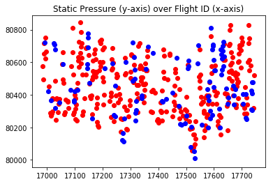

```python
plt.scatter(combined.index[combined['wind_mag_factor'] != 'Upper Quartile'], combined.static_pressure[combined['wind_mag_factor'] != 'Upper Quartile'],color='red')
plt.scatter(windy.index, windy.static_pressure, color='blue')
plt.title('Static Pressure (y-axis) over Flight ID (x-axis)')
plt.show()
```

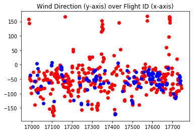

```python
plt.scatter(combined.index[combined['wind_mag_factor'] != 'Upper Quartile'], combined.wind_direction[combined['wind_mag_factor'] != 'Upper Quartile'],color='red')
plt.scatter(windy.index, windy.wind_direction, color='blue')
plt.title('Wind Direction (y-axis) over Flight ID (x-axis)')
plt.show()
```

### Results:

From the first plot above, it does not look like there is much of a difference between the **static pressure** of the 'Windy' flights and the rest of the flights; however, from the second plot, we can see that there may be a relationship between wind direction and wind magnitude, since it looks like there were some flights launched on days **without high winds** in which the wind_direction was also more East or South/East. **Unfortunately, a relationship between wind direction and wind magnitude still does not help us understand Zip plane performance!**

## Evaluating Wind Direction

#### Below we define a function that will categorize wind_direction as one of four new categories ('North', 'East', 'South', and 'West')

```python
print(min(combined.wind_direction), max(combined.wind_direction))
```

```
-176.13489801206418 168.17182500509878
```

```python
combined['wind_dir_factor'] = 'TBD'

def classify(wind_float):
    if (0<= wind_float) and (wind_float < 90):
        return 'North'
    elif (90 <= wind_float <180):
        return 'East'
    elif (-180 <= wind_float <0):
        return 'West'
    else:
        return 'South'
```

```python
combined.columns.get_loc('wind_direction')
```

```
10
```

```python
for index, row in combined.iterrows():
    combined.loc[index, 'wind_dir_factor'] = classify(combined.loc[index,'wind_direction'])
```

```python
combined.wind_dir_factor.head(10)
```

```
flight_id
16985    East
16987    East
16989    West
16990    West
16991    West
16994    West
16995    West
16996    West
17004    West
17007    West
Name: wind_dir_factor, dtype: object
```

```python
combined['wind_dir_factor'].value_counts()
```

```
West     391
East      18
North     18
Name: wind_dir_factor, dtype: int64
```

```python
combined['wind_dir_factor'].value_counts(normalize=True)
```

```
West     0.915691
East     0.042155
North    0.042155
Name: wind_dir_factor, dtype: float64
```

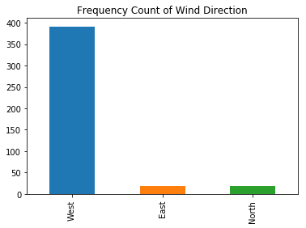

```python
plt.figure(figsize=(6,4))

combined['wind_dir_factor'].value_counts().plot('bar')
plt.title('Frequency Count of Wind Direction')
plt.show()
```

#### Again, we can see that there is a definite pattern for the wind direction, as it seems the majority of Zip flights have occured when there is West winds... Geographic location, or maybe even experimental design (ie the flight engineers are CHOOSING to fly Zip plans on days where there is west winds) are a few plausible explanations for this pattern.

## More on Relationships *Between* Variables

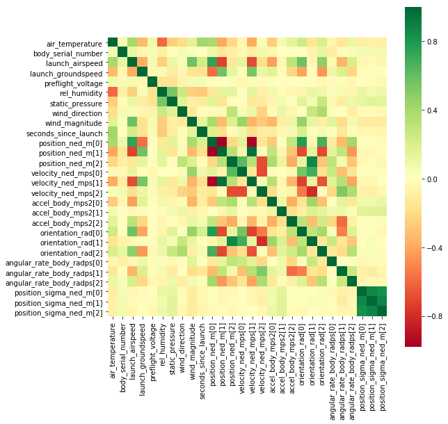

```python
import seaborn as sns

fig, ax = plt.subplots(figsize=(9,9))
sns.heatmap(combined.corr(), square=True, cmap='RdYlGn')
```

## A Simple Linear Regression Fit

Based off of some of the visuals and EDA we've completed above, we can select a few columns to focus on to see if we can draw some additional insights...

I was especially curious about evaluating whether uncontrollable features in our data set (ie weather or temperature) had any particular relationship with Zip performance. In the next exercises, I will look use the feature of wind_magnitude to evaluate the response of launch_airspeed (airspeed of the Zip plane during launch), **since these two variables were labeled as moderately correlated according to the heatmap above!**

```python
X = np.array(combined[['wind_magnitude']])
y = np.array(combined[['launch_airspeed']])

X = X.reshape(-1,1)
y=y.reshape(-1,1)
```

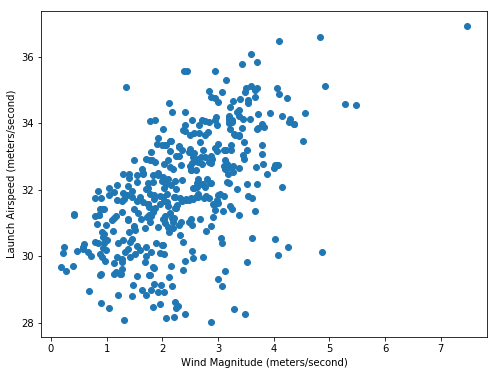

```python
plt.figure(figsize=(8,6))
plt.scatter(X,y)
plt.xlabel('Wind Magnitude (meters/second)')
plt.ylabel('Launch Airspeed (meters/second)')
plt.show()
```

#### As you can see, there is a positive correlation between the Wind Magnitude and the Launch Airspeed. A linear regression should be able to capture this trend...

#### Now we will fit a linear regression curve trained on the training data (which is randomly selected in the line below) in order to predict the launch airspeed of new observations that were not used to fit the model...

```python
X_train, X_test, y_train, y_test = train_test_split(X,y, test_size=.30, random_state=25)
```

```python
reg = LinearRegression()
```

```python
reg.fit(X_train, y_train)
```

```
LinearRegression(copy_X=True, fit_intercept=True, n_jobs=1, normalize=False)
```

```python
# We need to create a prediction space below! Here using
pred_space = np.linspace(min(X), max(X)).reshape(-1,1)
```

```python
y_pred = reg.predict(X_test)
```

To test the accuracy of this model, we can calculate R^2 to see the amount of variance in the target variable that is predicted from the explanatory variable. The best possible score is 1, which would mean that 100% of the variance in the model is explained by the regression fit...

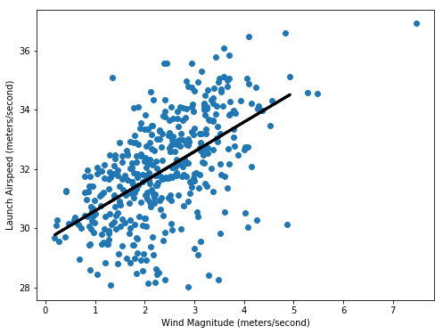

```python
plt.figure(figsize=(8,6))
plt.scatter(X,y)
plt.xlabel('Wind Magnitude (meters/second)')
plt.ylabel('Launch Airspeed (meters/second)')

plt.plot(X_test, y_pred, color='black', linewidth=3)
plt.show()
```

```python
reg.score(X_test, y_test)
```

```
0.37302811892451504
```

### Results

Although the regression line plot looks like the curve fit well to the data points, the R^2 accuracy score is only .37 approximately! These results show a poor fit and might mean that our linear model is too simple for the data and that we might want to consider a more complex option such as a polynomial curve or a QDA or LDA...

# Conclusions

The work presented here serves as only *first step* of many in order to reach insights that can help identify and understand aspects of the Zip plane performance.

So far, we have successfully joined the data sets together by fixing one point of relative time after Zip launch (here we chose the last record for each flight - at 15 seconds after it's take-off). We have also identified observations with missing values and removed them. And finally, we took a glimpse at some of the distributions of variables in our data, as well as relationships between some of these variables.

# What's Next?

A few tasks that could be done to continue this EDA project include the following:

- Removing the outliers in the data to draw more accurate conclusions
- Improving and adjusting the linear model above and also fitting additional regression models to the data to in order to draw conclusions about the patterns
- Looking to see if there are any relationships between variables that are measured in the same directions (ie relationships between position, velocity, and acceleration variables as grouped by their directional x, y, and z components)
- Looking more closely at patterns that may arise from flights with the *highest* performance rates... This means, first defining what is means for a flight to be 'high-performing,' and then creating a subset of the highest performing planes and checking for any noticeable patterns.